# COVID-19 Socio-Economic Dashboard for Bangladesh[^1]

Dec 2, 2020

Tracking Economic Consequences and Responses to COVID-19 in Bangladesh. Access to information on key economic indicators is essential to help policy-makers in Bangladesh respond to the Covid-19 pandemic. The following dashboard provides data on current economic conditions and trends from administrative and phone based survey in Bangladesh.

## Food Security & Market Access

### Trends

> Percentage of Households Skipping Meals

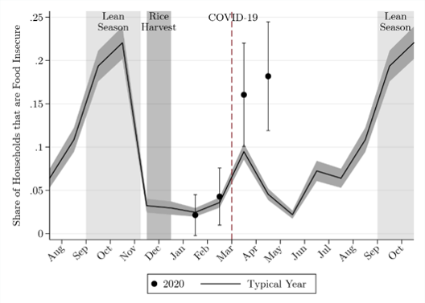

Changes in food insecurity compared to the previous year, Northern Bangladesh (NLS)

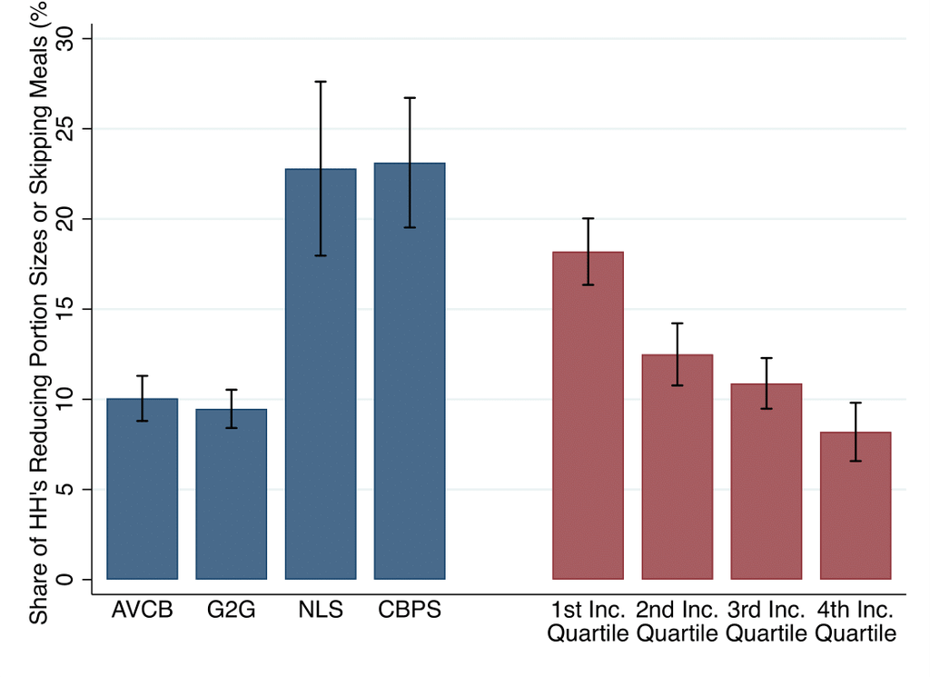

Reported food insecurity in [April] across multiple samples

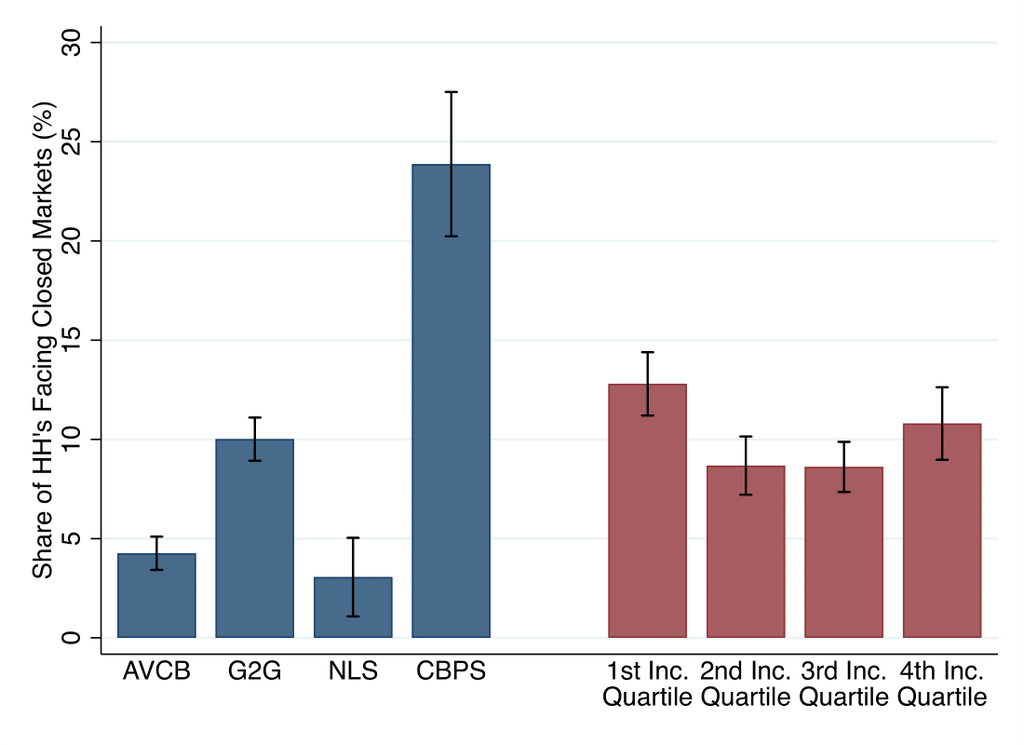

Reported market closures in [April] across multiple samples

> Change in commodity prices over time

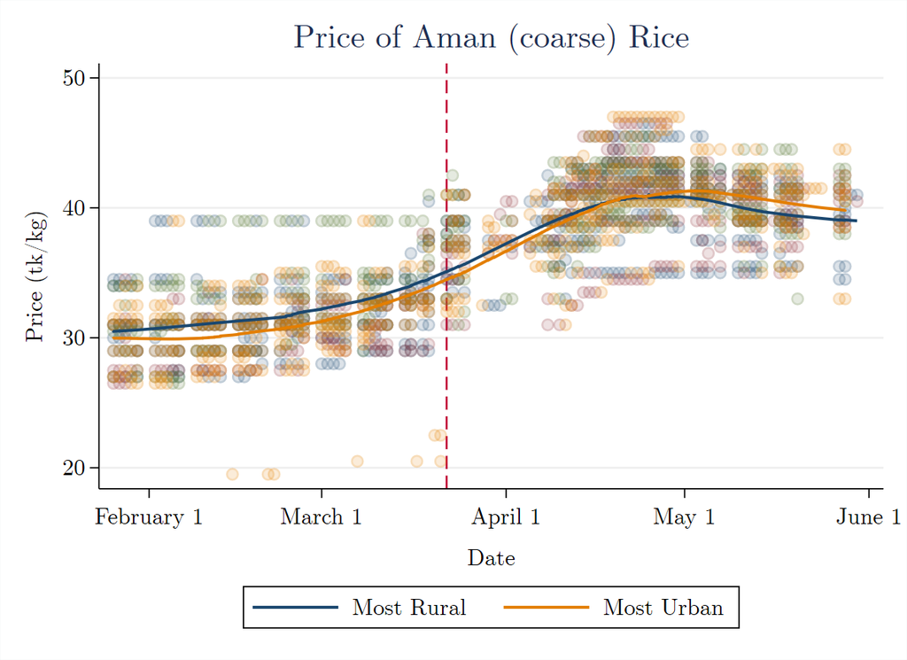

Daily district level market price of aman (coarse) rice

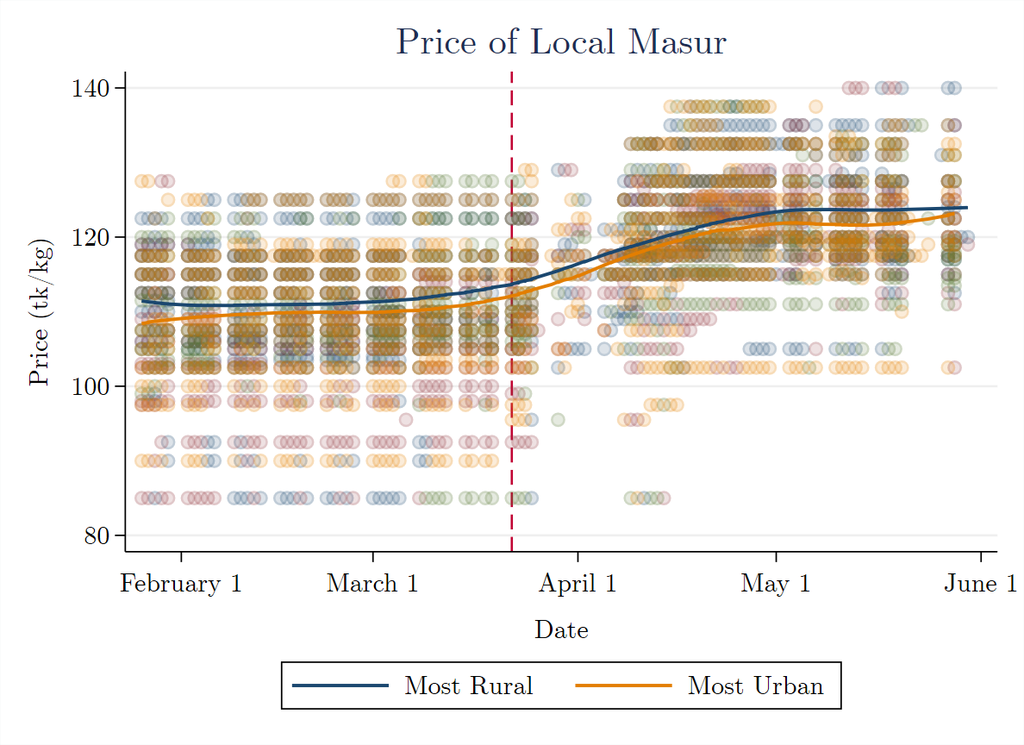

Daily district level market price of local masur

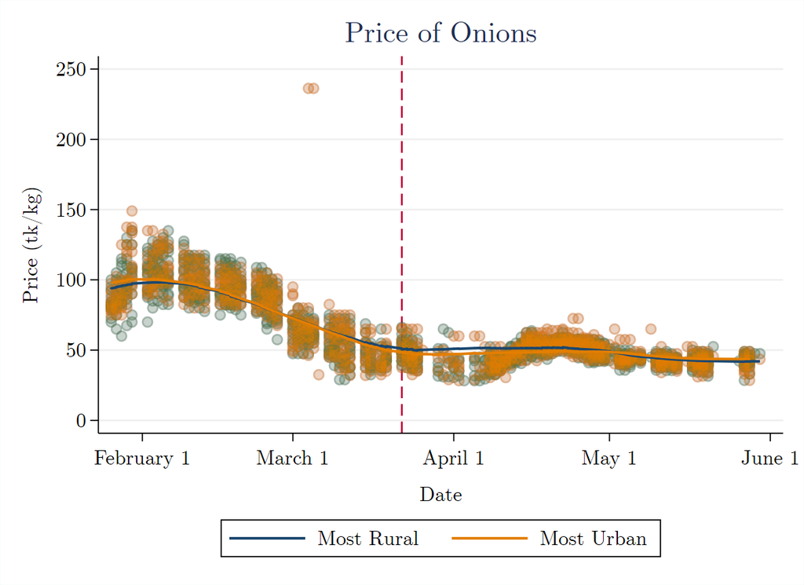

Daily district level market price of onions

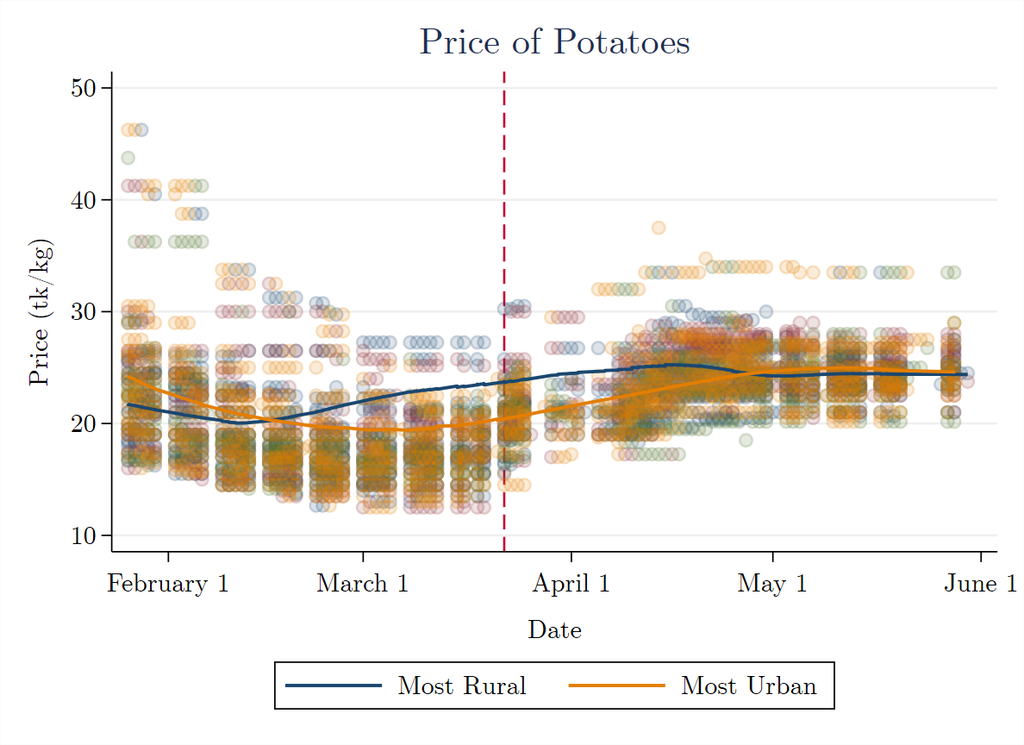

Daily district level market price of potatoes

### Definition of Measures

Data definitions:

[output not shown]

## Income Effect

### Trends

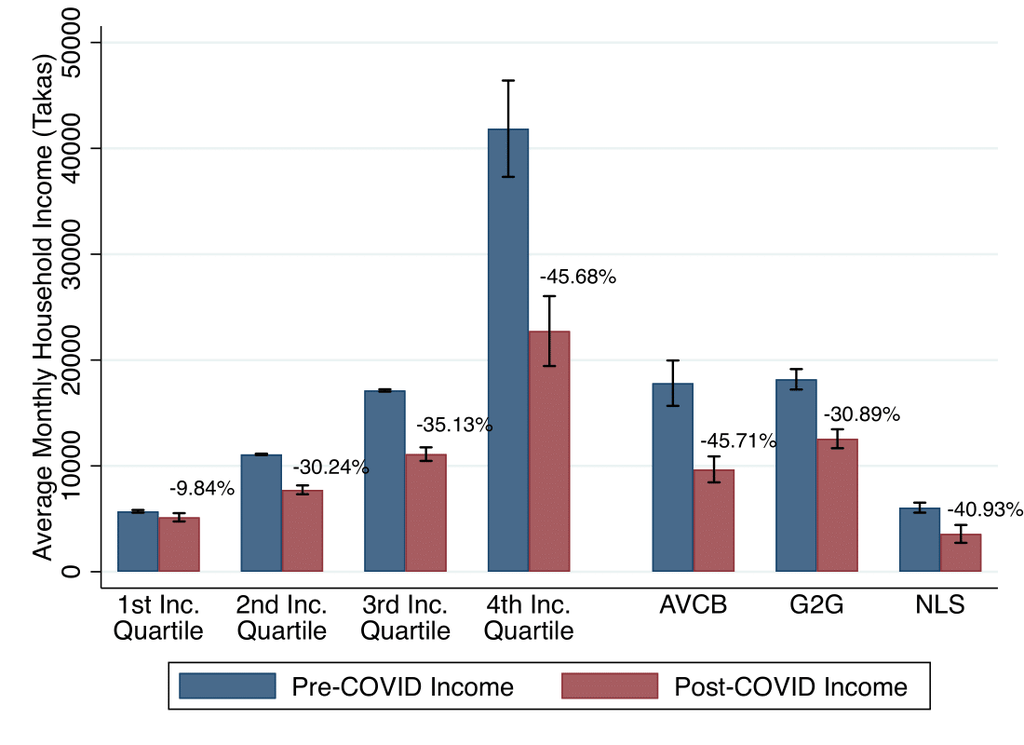

Changes in monthly income before and after COVID-19 lockdown

### Definition of Measures

Data definitions:

[output not shown]

## Exposure to Migration

### Trends

> Food security for migrant households

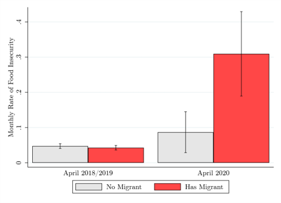

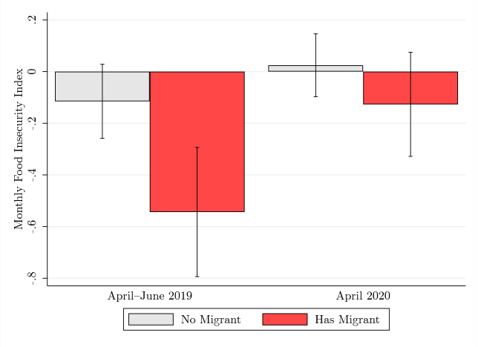

> Change in income for migrant households

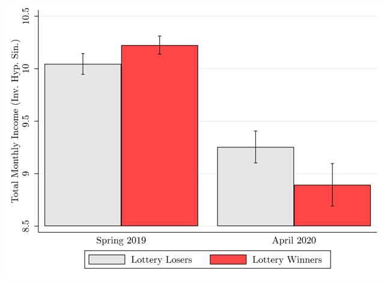

### Maps

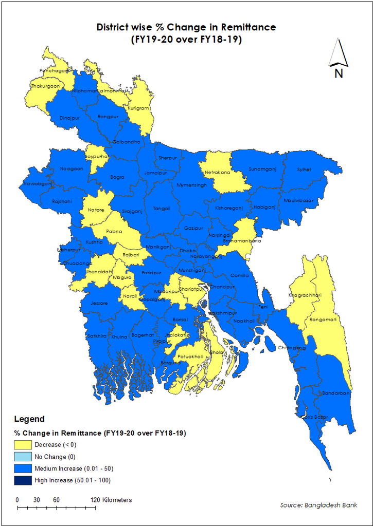

### Definition of Measures

Data definitions:

[output not shown]

### Policy Briefs

- [Using Migration Patterns to Predict COVID-19 Risk Exposure in Developing Countries](https://yrise.yale.edu/using-migration-patterns-to-predict-covid-19-risk-exposure-in-developing-countries/)
- [Migration and the Labor Market Impacts of COVID-19](https://yrise.yale.edu/migration-and-the-labor-market-impacts-of-covid-19/)

## Social Transfers

### Trends

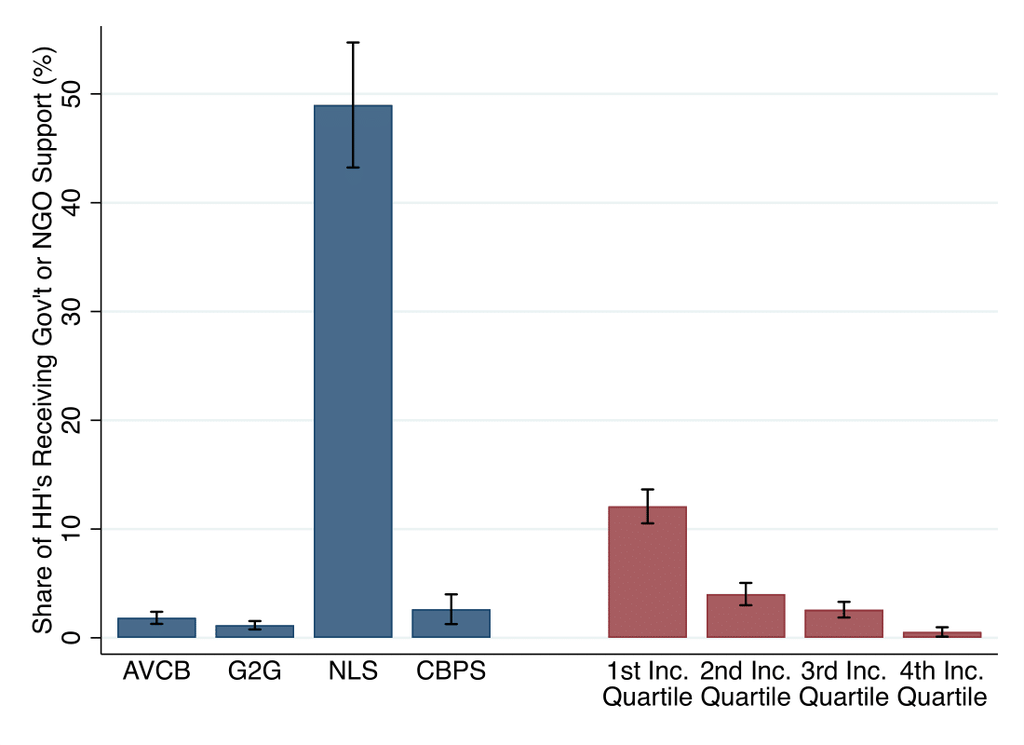

Reported receipts of Government or NGO aid in [April] across multiple samples

### Maps

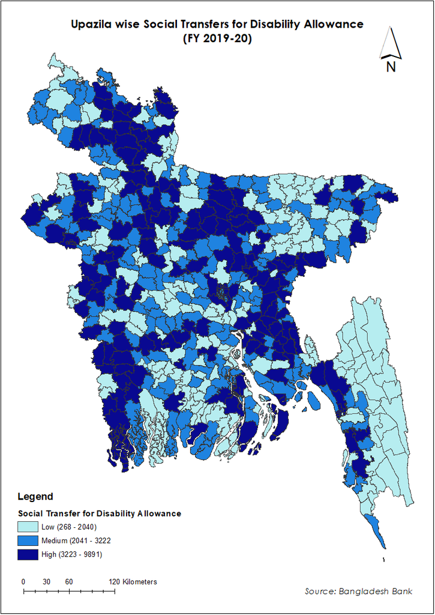

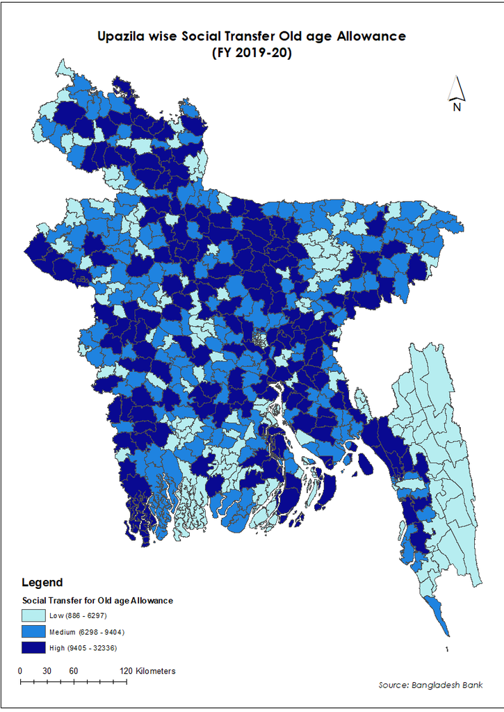

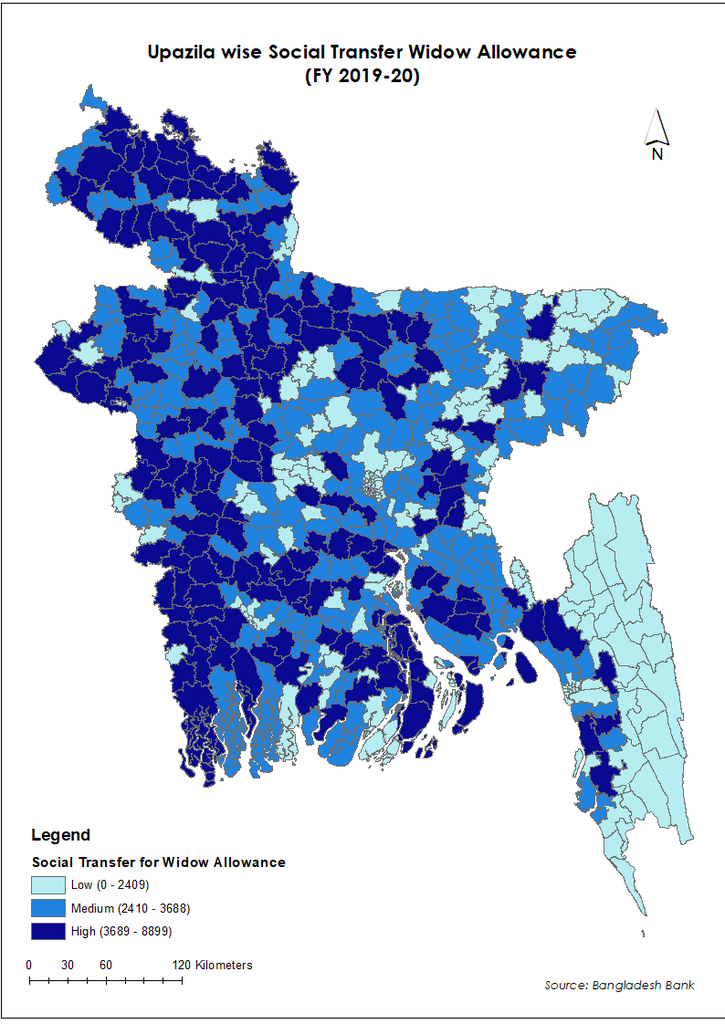

### Definition of Measures

Data definitions:

[output not shown]

## COVID-19 Awareness/Symptoms

### Trends

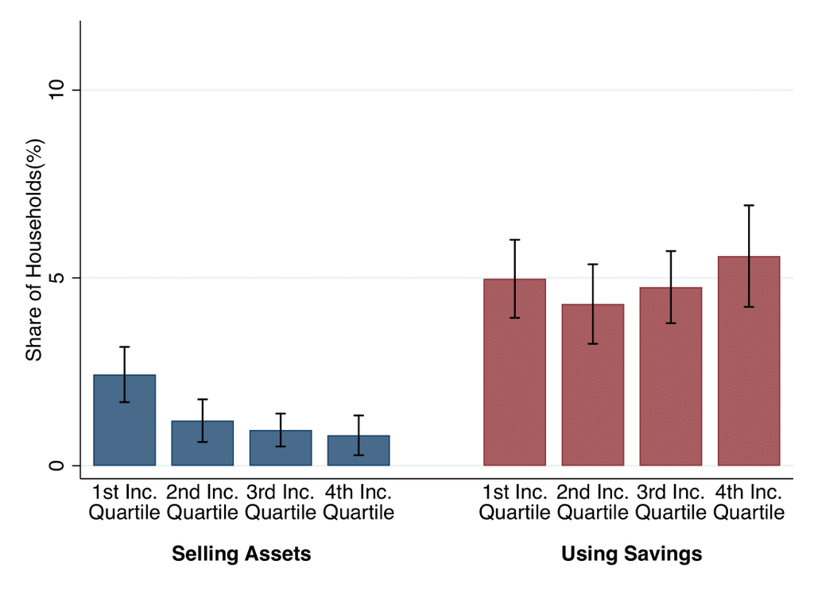

Percentage of households selling assets to deal with Covid

### Definition of Measures

[output not shown]

## All Policy Briefs

- [Using Migration Patterns to Predict COVID-19 Risk Exposure in Developing Countries](https://yrise.yale.edu/using-migration-patterns-to-predict-covid-19-risk-exposure-in-developing-countries/)
- [Migration and the Labor Market Impacts of COVID-19](https://yrise.yale.edu/migration-and-the-labor-market-impacts-of-covid-19/)
- [Should Low-Income Countries Impose the Same Social Distancing Guidelines as Europe and North America to Halt the Spread of Covid-19?](https://yrise.yale.edu/should-low-income-countries-impose-the-same-social-distancing-guidelines-as-europe-and-north-america-to-halt-the-spread-of-covid-19/)
- [Prevalence of COVID-19 symptoms, risk factors, and health behaviors in host and refugee communities in Cox’s Bazar: a representative panel study](https://yrise.yale.edu/prevalence-of-covid-19-symptoms-risk-factors-and-health-behaviors-in-host-and-refugee-communities-in-coxs-bazar-a-representative-panel-study/)
- [Changes in Religious Gatherings & Practices to Curb COVID-19](https://yrise.yale.edu/changes-in-religious-gatherings-practices-to-curb-covid-19/)
[^1]: Collaborative effort between the a2i and Y-RISE